# DATA607: Final Project

Sinchana Gupta Garla Venkatesha

2024-12-06

```r
knitr::opts_chunk$set(echo = FALSE)
library(COVID19)
library(dplyr)
```

```r
library(ggplot2)
library(reshape2)
library(cluster)
library(caret)
library(xgboost)
library(pROC)
library(gridExtra)
library(boot)
library(patchwork)
```

# Understanding COVID-19 Case Fatality Rates: A Data-Driven Approach

## Introduction

The COVID-19 pandemic has disrupted lives globally, with Case Fatality Rate (CFR) emerging as a key measure of severity. CFR, calculated as the ratio of deaths to confirmed cases, varies significantly across regions due to factors such as testing rates, vaccination policies, and government responses.

### Objectives

**Primary Goal**: Identify the drivers of high CFR (CFR > 3%) and classify high-risk regions using machine learning. **Secondary Goals**: (i) Analyze the relationships between government policies, testing, and CFR. (ii) Examine regional disparities and trends over time.

## Step-1: Data Collection and Preparation

The dataset, sourced from the COVID19 R package, provides detailed information on COVID-19 cases, deaths, testing, and policies at a regional level. To ensure reliability, the following data cleaning steps were applied:

1. **Grouping by Region**: Countries were categorized into major regions (Americas, Asia, Europe, Other) for comparative analysis.
2. **Handling Missing Values**: Numerical values were imputed with medians, and categorical variables with “Unknown”.
3. **Derived Metrics**: Tests_Per_Capita was calculated as tests / population to standardize testing data across regions.

```r
# Data preparation steps
df <- covid19(level = 2) %>%
  mutate(
    state = administrative_area_level_2,
    region = case_when(
      administrative_area_level_1 %in% c("United States", "Canada", "Mexico", "Brazil", "Argentina") ~ "Americas",
      administrative_area_level_1 %in% c("China", "India", "Japan", "Thailand") ~ "Asia",
      administrative_area_level_1 %in% c("France", "Germany", "Italy", "Spain") ~ "Europe",
      TRUE ~ "Other"
    ),
    Tests_Per_Capita = tests / population
  ) %>%
  mutate(across(where(is.numeric), ~ ifelse(is.na(.), median(., na.rm = TRUE), .)),
         across(where(is.character), ~ ifelse(is.na(.), "Unknown", .)))
```

[output not shown]

## Step-2: Exploratory Data Analysis (EDA)

#### CFR Trends Over Time

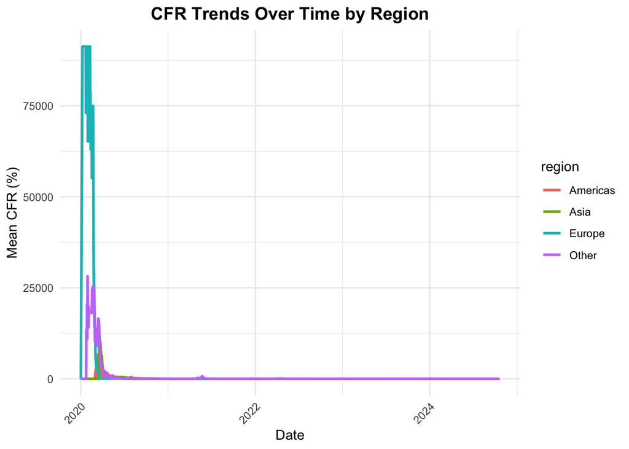

```r
# Visualizing CFR trends by region
df <- df %>% mutate(CFR = ifelse(confirmed > 0, (deaths / confirmed) * 100, NA))

df %>%
  group_by(region, date) %>%
  summarise(mean_CFR = mean(CFR, na.rm = TRUE)) %>%
  ggplot(aes(x = date, y = mean_CFR, color = region)) +
  geom_line(size = 1) +
  labs(title = "CFR Trends Over Time by Region", x = "Date", y = "Mean CFR (%)") +
  theme_minimal() +
  theme(plot.title = element_text(face = "bold", hjust = 0.5, size = 14),
        axis.text.x = element_text(angle = 45, hjust = 1))
```

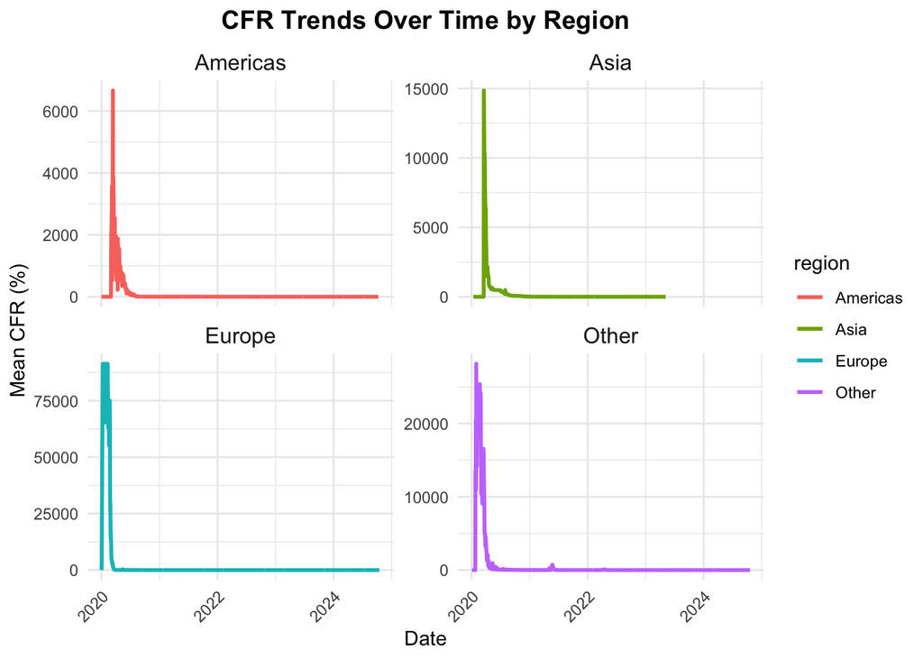

```r
df %>%
  group_by(region, date) %>%
  summarise(mean_CFR = mean(CFR, na.rm = TRUE)) %>%
  ggplot(aes(x = date, y = mean_CFR, color = region)) +
  geom_line(size = 1) +
  labs(title = "CFR Trends Over Time by Region", x = "Date", y = "Mean CFR (%)") +
  facet_wrap(~region, scales = "free_y") +  # Separate panels by region
  theme_minimal() +
  theme(
    plot.title = element_text(face = "bold", hjust = 0.5, size = 14),
    axis.text.x = element_text(angle = 45, hjust = 1),
    strip.text = element_text(size = 12)  # Adjust facet labels
  )
```

#### Relationship Between Tests and CFR

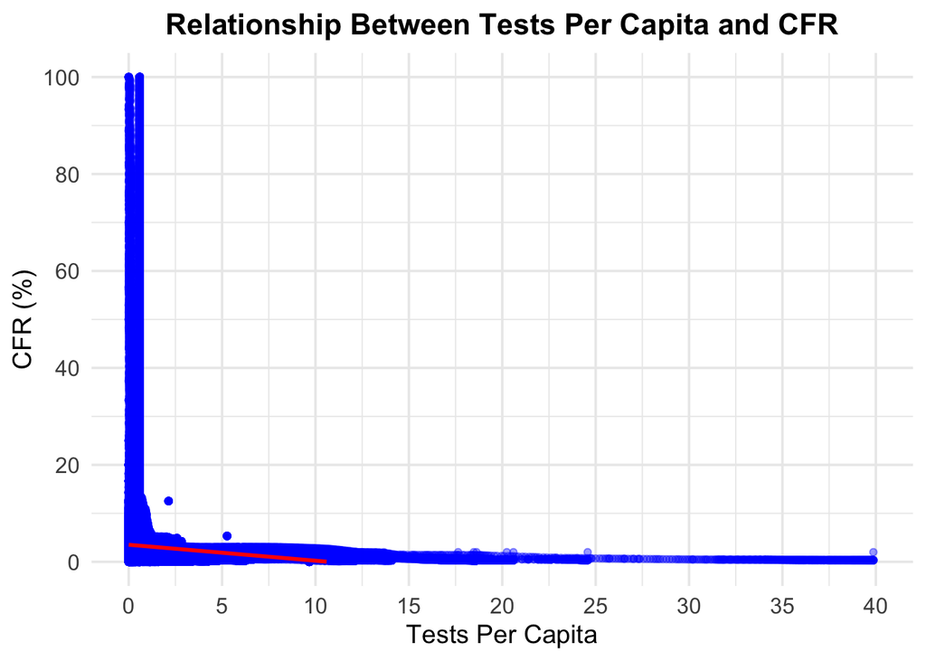

```r
# Improve readability of the CFR vs. Tests Per Capita plot
df %>%
  ggplot(aes(x = Tests_Per_Capita, y = CFR)) +
  geom_point(alpha = 0.4, size = 1.5, color = "blue") +  # Add transparency and color
  geom_smooth(method = "lm", color = "red", size = 1) +  # Thicker regression line
  scale_y_continuous(limits = c(0, 100), breaks = seq(0, 100, 20)) +  # Set y-axis limits and ticks
  scale_x_continuous(limits = c(0, 40), breaks = seq(0, 40, 5)) +  # Set x-axis limits and ticks
  labs(
    title = "Relationship Between Tests Per Capita and CFR",
    x = "Tests Per Capita",
    y = "CFR (%)"
  ) +
  theme_minimal(base_size = 14) +  # Increase base font size
  theme(
    plot.title = element_text(face = "bold", hjust = 0.5, size = 16),  # Bold, centered title
    axis.title = element_text(size = 14),  # Larger axis labels
    axis.text = element_text(size = 12)  # Larger tick labels
  )
```

#### Regional Disparities in CFR

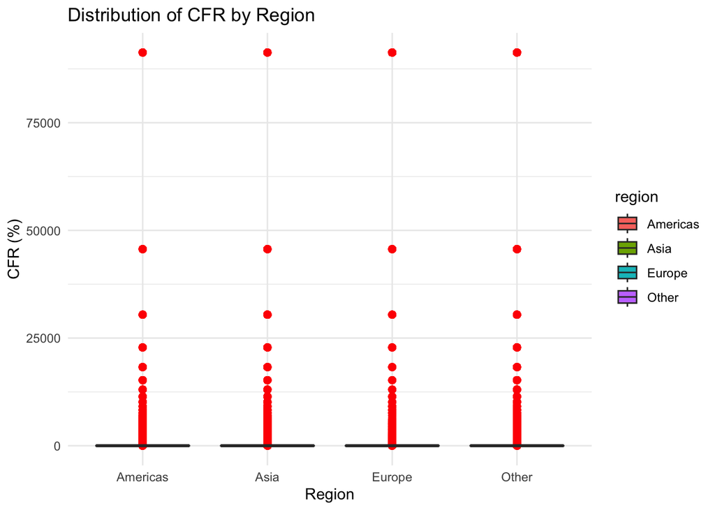

```r
# CFR distribution by region
df %>%
  ggplot(aes(x = region, y = CFR, fill = region)) +
  geom_boxplot(outlier.color = "red", outlier.size = 2) +
  labs(title = "Distribution of CFR by Region", x = "Region", y = "CFR (%)") +
  theme_minimal()
```

#### Correlation Between Predictors (Heatmap)

**Aim:** Highlight how different features (e.g., testing rates, government policies) correlate with CFR.

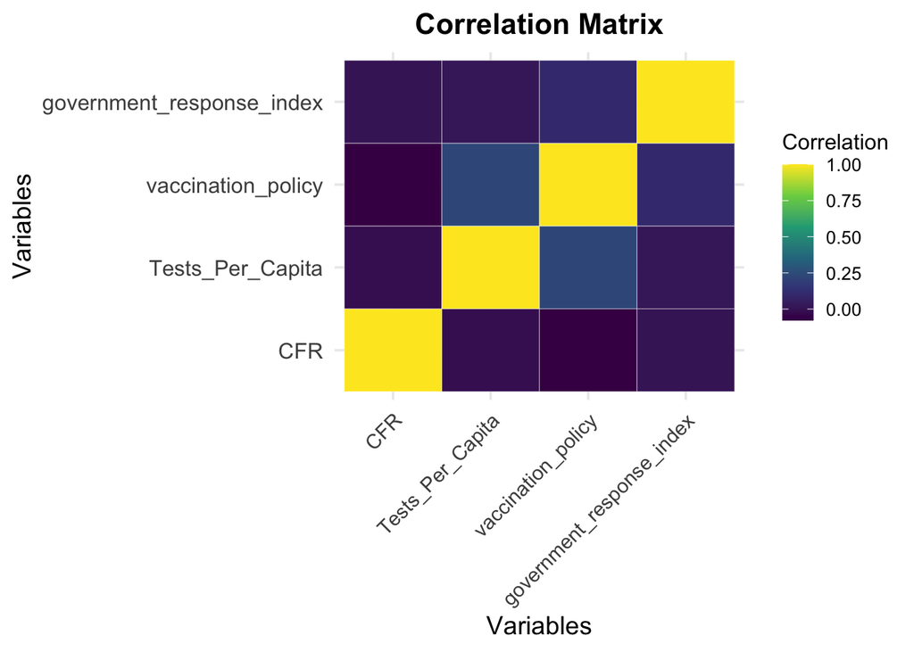

```r
cor_data <- df %>%
  select(CFR, Tests_Per_Capita, vaccination_policy, government_response_index) %>%
  cor(use = "complete.obs")

melted_cor <- melt(cor_data)

ggplot(melted_cor, aes(Var1, Var2, fill = value)) +
  geom_tile(color = "white") +
  # Add white grid lines
  scale_fill_viridis_c() +
  labs(
    title = "Correlation Matrix",
    x = "Variables",
    y = "Variables",
    fill = "Correlation"
  ) +
  theme_minimal(base_size = 14) +
  theme(
    plot.title = element_text(face = "bold", hjust = 0.5, size = 16),
    axis.text.x = element_text(angle = 45, vjust = 1, hjust = 1),
    # Rotate x-axis labels
    axis.text.y = element_text(size = 12),
    # Increase y-axis label size
    legend.title = element_text(size = 12),
    # Adjust legend title size
    legend.text = element_text(size = 10)
    # Adjust legend text size
  )
```

## Step 3: Analytical Insights

#### Clustering Analysis

Regions were grouped into clusters based on CFR, Tests_Per_Capita, population, and government response index.

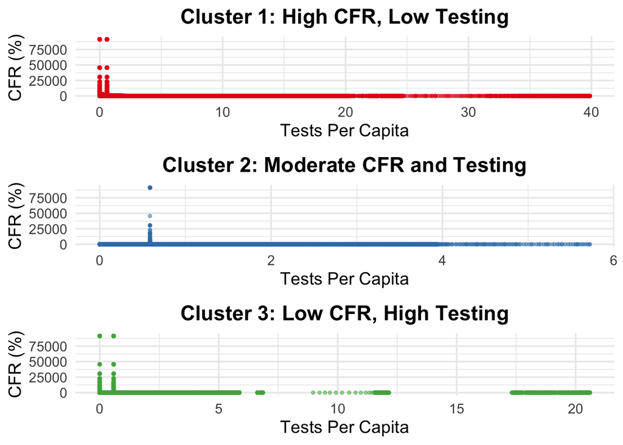

```r
# Ensure valid rows are identified for clustering
valid_rows <- complete.cases(df[, c("CFR", "Tests_Per_Capita", "population", "government_response_index")])

# K-means clustering
clustering_data <- scale(df[valid_rows, c("CFR", "Tests_Per_Capita", "population", "government_response_index")])
set.seed(42)
kmeans_result <- kmeans(clustering_data, centers = 3)
df$cluster <- factor(ifelse(valid_rows, kmeans_result$cluster, NA))

# Define colors for clusters
cluster_colors <- c("1" = "#E41A1C", "2" = "#377EB8", "3" = "#4DAF4A")

# Plot for Cluster 1
plot1 <- ggplot(df %>% filter(cluster == "1"), aes(x = Tests_Per_Capita, y = CFR)) +
  geom_point(color = cluster_colors["1"], alpha = 0.5, size = 1) +
  labs(title = "Cluster 1: High CFR, Low Testing", x = "Tests Per Capita", y = "CFR (%)") +
  theme_minimal(base_size = 14) +
  theme(plot.title = element_text(face = "bold", hjust = 0.5))

# Plot for Cluster 2
plot2 <- ggplot(df %>% filter(cluster == "2"), aes(x = Tests_Per_Capita, y = CFR)) +
  geom_point(color = cluster_colors["2"], alpha = 0.5, size = 1) +
  labs(title = "Cluster 2: Moderate CFR and Testing", x = "Tests Per Capita", y = "CFR (%)") +
  theme_minimal(base_size = 14) +
  theme(plot.title = element_text(face = "bold", hjust = 0.5))

# Plot for Cluster 3
plot3 <- ggplot(df %>% filter(cluster == "3"), aes(x = Tests_Per_Capita, y = CFR)) +
  geom_point(color = cluster_colors["3"], alpha = 0.5, size = 1) +
  labs(title = "Cluster 3: Low CFR, High Testing", x = "Tests Per Capita", y = "CFR (%)") +
  theme_minimal(base_size = 14) +
  theme(plot.title = element_text(face = "bold", hjust = 0.5))

# Arrange the plots vertically
grid.arrange(plot1, plot2, plot3, ncol = 1)
```

#### Regression Analysis

To identify the drivers of CFR, a multivariate regression model was fitted:

```r
regression_model <- lm(CFR ~ Tests_Per_Capita + vaccination_policy + government_response_index + population, data = df)
summary(regression_model)
```

```
##
## Call:
## lm(formula = CFR ~ Tests_Per_Capita + vaccination_policy + government_response_index +
##     population, data = df)
##
## Residuals:
##    Min     1Q Median     3Q    Max
##   -636   -397    -51     44  91152
##
## Coefficients:
##                             Estimate Std. Error t value Pr(>|t|)
## (Intercept)                5.584e+02  7.007e+00  79.693   <2e-16 ***
## Tests_Per_Capita          -3.887e-01  1.734e+00  -0.224    0.823
## vaccination_policy        -1.110e+02  1.551e+00 -71.569   <2e-16 ***
## government_response_index  1.030e+00  8.497e-02  12.125   <2e-16 ***
## population                -3.561e-06  3.042e-07 -11.706   <2e-16 ***
## ---
## Signif. codes:  0 '***' 0.001 '**' 0.01 '*' 0.05 '.' 0.1 ' ' 1
##
## Residual standard error: 2899 on 851938 degrees of freedom
##   (10577 observations deleted due to missingness)
## Multiple R-squared:  0.006419,   Adjusted R-squared:  0.006414
## F-statistic:  1376 on 4 and 851938 DF,  p-value: < 2.2e-16
```

#### Classification of High-Risk Regions

Regions with CFR > 3% were classified as high-risk using XGBoost.

```r
# XGBoost Classification
df_clean <- df %>%
  mutate(high_risk = ifelse(CFR > 3, 1, 0)) %>%
  filter(!is.na(high_risk), !is.na(Tests_Per_Capita), !is.na(vaccination_policy), !is.na(government_response_index))

train_index <- createDataPartition(df_clean$high_risk, p = 0.8, list = FALSE)
train_data <- df_clean[train_index, ]
test_data <- df_clean[-train_index, ]

train_matrix <- as.matrix(train_data[, c("Tests_Per_Capita", "vaccination_policy", "government_response_index")])
test_matrix <- as.matrix(test_data[, c("Tests_Per_Capita", "vaccination_policy", "government_response_index")])

xgb_model <- xgboost(data = train_matrix, label = train_data$high_risk, nrounds = 100, objective = "binary:logistic", verbose = 0)

# Evaluate
xgb_predictions <- predict(xgb_model, test_matrix)
confusionMatrix(as.factor(ifelse(xgb_predictions > 0.5, 1, 0)), as.factor(test_data$high_risk))
```

```
## Confusion Matrix and Statistics
##
##           Reference
## Prediction      0      1
##          0 125301  19894
##          1   5391  19802
##
##                Accuracy : 0.8516
##                  95% CI : (0.8499, 0.8533)
##     No Information Rate : 0.767
##     P-Value [Acc > NIR] : < 2.2e-16
##
##                   Kappa : 0.5243
##
##  Mcnemar's Test P-Value : < 2.2e-16
##
##             Sensitivity : 0.9588
##             Specificity : 0.4988
##          Pos Pred Value : 0.8630
##          Neg Pred Value : 0.7860
##              Prevalence : 0.7670
##          Detection Rate : 0.7354
##    Detection Prevalence : 0.8521
##       Balanced Accuracy : 0.7288
##
##        'Positive' Class : 0
##
```

## Step 4: Measurements of Uncertainty

#### Confidence Intervals for Tests_Per_Capita

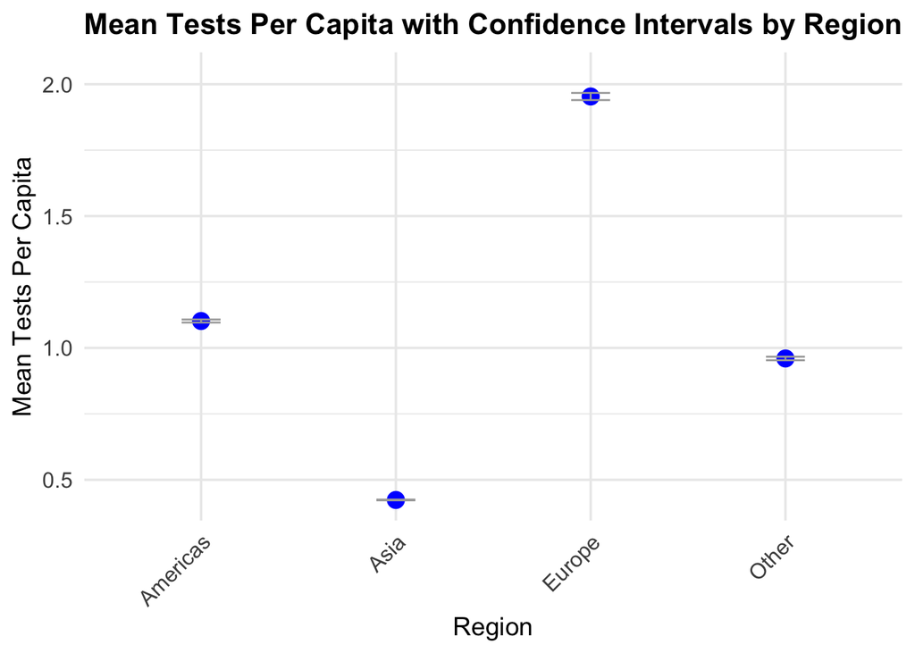

```r
ci_tests <- df %>%
  group_by(region) %>%
  summarise(
    Mean_Tests_Per_Capita = mean(Tests_Per_Capita, na.rm = TRUE),
    SD = sd(Tests_Per_Capita, na.rm = TRUE),
    N = n(),
    CI_Lower = Mean_Tests_Per_Capita - qt(0.975, N - 1) * (SD / sqrt(N)),
    CI_Upper = Mean_Tests_Per_Capita + qt(0.975, N - 1) * (SD / sqrt(N))
  )

# Plot with confidence intervals
ggplot(ci_tests, aes(x = region, y = Mean_Tests_Per_Capita)) +
  geom_point(size = 4, color = "blue") +
  geom_errorbar(aes(ymin = CI_Lower, ymax = CI_Upper), width = 0.2, color = "darkgray") +
  labs(title = "Mean Tests Per Capita with Confidence Intervals by Region",
       x = "Region", y = "Mean Tests Per Capita") +
  scale_y_continuous(expand = expansion(mult = c(0.05, 0.1))) + # Add space above and below the plot
  theme_minimal(base_size = 14) +
  theme(
    plot.title = element_text(face = "bold", hjust = 0.5, size = 16),
    axis.title = element_text(size = 14),
    axis.text.x = element_text(angle = 45, hjust = 1, size = 12), # Rotate x-axis labels
    axis.text.y = element_text(size = 12)
  )
```

## Conclusions and Recommendations

#### Recommendations:

1. Expand testing infrastructure in underperforming regions.
2. Invest in vaccination campaigns.
3. Tailor government responses to regional needs.

#### Future Directions:

- Incorporate additional factors like healthcare capacity and demographics. Extend analysis to finer-grained data for localized insights.